# Clase 4.0 Análisis

## Preprocesamiento

- Estandarización y escalamiento con `scale`.

```r
x <- c(1, 2, 3)
scale(x, center = T)[1:3]
```

```
## [1] -1  0  1
```

```r
(x - mean(x)) / sd(x) # manual
```

```
## [1] -1  0  1
```

```r
scale(x, center = F)[1:3]
```

```
## [1] 0.3779645 0.7559289 1.1338934
```

```r
x / sqrt(sum(x^2) / (length(x) - 1)) # manual
```

```
## [1] 0.3779645 0.7559289 1.1338934
```

## Estadística descriptiva

## Estadística descriptiva

- Medidas de tendencia central.

```r
# Media
mean(mtcars$mpg) # emplea na.rm = T si hay valores faltantes
```

```
## [1] 20.09062
```

```r
# Mediana
median(mtcars$mpg)
```

```
## [1] 19.2
```

```r
# Moda
getmode <- function(v) {
   uniqv <- unique(v)
   uniqv[which.max(tabulate(match(v, uniqv)))]
}
getmode(mtcars$mpg)
```

```
## [1] 21
```

## Estadística descriptiva

- Medidas de dispersión.

```r
# Desviación estándar
sd(mtcars$mpg)
```

```
## [1] 6.026948
```

```r
# Cuantiles
quantile(mtcars$mpg)
```

```
##     0%    25%    50%    75%   100%
## 10.400 15.425 19.200 22.800 33.900
```

```r
# Rango intercuantil
IQR(mtcars$mpg)
```

```
## [1] 7.375
```

```r
# Rango total
range(mtcars$mpg)
```

```
## [1] 10.4 33.9
```

## Estadística descriptiva

- Tamaños de muestra.

```r
length(mtcars$mpg) # Número de observaciones
```

```
## [1] 32
```

```r
length(mtcars) # Si es un df, número de variables (columnas)
```

```
## [1] 11
```

```r
dim(mtcars) # Si es matirz o df, núm. de observaciones x núm. de variables
```

```
## [1] 32 11
```

## Estadística descriptiva

- `dplyr::group_by` y `dplyr::summarize`

```r
library(dplyr)
library(magrittr)

mtcars %>%
  group_by(cyl) %>%
  summarise(n = n(), mean_mpg = mean(mpg), sd_mpg = sd(mpg))
```

```
## # A tibble: 3 × 4
##     cyl     n mean_mpg sd_mpg
##   <dbl> <int>    <dbl>  <dbl>
## 1     4    11     26.7   4.51
## 2     6     7     19.7   1.45
## 3     8    14     15.1   2.56
```

## Estadística descriptiva

- `dplyr::summarize_all`

```r
library(dplyr)
library(magrittr)

mtcars %>%
  group_by(cyl) %>%
  summarise_all(list(~mean(.)))
```

```
## # A tibble: 3 × 11
##     cyl   mpg  disp    hp  drat    wt  qsec    vs    am  gear  carb
##   <dbl> <dbl> <dbl> <dbl> <dbl> <dbl> <dbl> <dbl> <dbl> <dbl> <dbl>
## 1     4  26.7  105.  82.6  4.07  2.29  19.1 0.909 0.727  4.09  1.55
## 2     6  19.7  183. 122.   3.59  3.12  18.0 0.571 0.429  3.86  3.43
## 3     8  15.1  353. 209.   3.23  4.00  16.8 0     0.143  3.29  3.5
```

## Estadística inferencial

## Estadística inferencial

- `wilcox.test()` *dos* muestras, *independientes* o *pareadas*, **datos no paramétricos**.

```r
?airquality
head(airquality)
```

```r
wilcox.test(Ozone ~ Month, data = airquality %>%
              filter(Month %in% c(5, 8))) # paired = T si son muestras pareadas
```

```
##
##  Wilcoxon rank sum test with continuity correction
##
## data:  Ozone by Month
## W = 127.5, p-value = 0.0001208
## alternative hypothesis: true location shift is not equal to 0
```

## Estadística inferencial

- `kruskal.test()` *tres o más* muestras *independientes*, **datos no paramétricos**.

```r
?PlantGrowth
head(PlantGrowth)
```

```r
kruskal.test(weight ~ group, data = PlantGrowth)
```

```
##
##  Kruskal-Wallis rank sum test
##
## data:  weight by group
## Kruskal-Wallis chi-squared = 7.9882, df = 2, p-value = 0.01842
```

```r
# posthocs con pairwise.wilcox.test
pairwise.wilcox.test(PlantGrowth$weight, PlantGrowth$group, p.adjust.method = "BH")
```

```
##
##  Pairwise comparisons using Wilcoxon rank sum test with continuity correction
##
## data:  PlantGrowth$weight and PlantGrowth$group
##
##      ctrl  trt1
## trt1 0.199 -
## trt2 0.095 0.027
##
## P value adjustment method: BH
```

## Estadística inferencial

- `friedman.test()` Tres o más muestras *repetidas*, **datos no paramétricos**.

```r
data("selfesteem", package = "datarium")
?selfesteem
head(selfesteem)
```

```r
# operador barra | marca el elemento que identifica las repeticiones
friedman.test(score ~ time | id, data = selfesteem %>%
                tidyr::gather(time, score, -id))
```

```
##
##  Friedman rank sum test
##
## data:  score and time and id
## Friedman chi-squared = 18.2, df = 2, p-value = 0.0001117
```

## Estadística inferencial

- Correlación `cor()` entre dos vectores.

```r
cor(airquality$Ozone,airquality$Wind, use = "complete.obs")
```

```
## [1] -0.6015465
```

## Estadística inferencial

- Correlación `cor()` de una matriz o df.

```r
cor(airquality, use = "complete.obs")
```

```
##                Ozone     Solar.R        Wind       Temp        Month
## Ozone    1.000000000  0.34834169 -0.61249658  0.6985414  0.142885168
## Solar.R  0.348341693  1.00000000 -0.12718345  0.2940876 -0.074066683
## Wind    -0.612496576 -0.12718345  1.00000000 -0.4971897 -0.194495804
## Temp     0.698541410  0.29408764 -0.49718972  1.0000000  0.403971709
## Month    0.142885168 -0.07406668 -0.19449580  0.4039717  1.000000000
## Day     -0.005189769 -0.05775380  0.04987102 -0.0965458 -0.009001079
##                  Day
## Ozone   -0.005189769
## Solar.R -0.057753801
## Wind     0.049871017
## Temp    -0.096545800
## Month   -0.009001079
## Day      1.000000000
```

## Estadística inferencial

- `cor.test()` prueba de asociación o correlación entre muestras pareadas.

```r
cor.test(women$height, women$weight, method = "pearson") # "spearman" si no paramétricos
```

```
##
##  Pearson's product-moment correlation
##
## data:  women$height and women$weight
## t = 37.855, df = 13, p-value = 1.091e-14
## alternative hypothesis: true correlation is not equal to 0
## 95 percent confidence interval:
##  0.9860970 0.9985447
## sample estimates:
##       cor
## 0.9954948
```

## Estadística inferencial

- Ajuste de modelos lineales `lm()` y `cor.test()`

```r
lm1 <- lm(Volume ~ Height, trees)
lm2 <- lm(Girth ~ Height, trees)
cor(lm1$residuals, lm2$residuals) # correlación controlando por Height
```

```
## [1] 0.9586123
```

## Estadística inferencial

- `chisq.test()` prueba de independencia con frecuencias.

```r
data(survey, package = "MASS")
?survey
head(survey)
```

```r
tbl <- table(survey$Smoke, survey$Exer)
chisq.test(tbl)
```

```
##
##  Pearson's Chi-squared test
##
## data:  tbl
## X-squared = 5.4885, df = 6, p-value = 0.4828
```

## Estadística inferencial

- `t.test()` para una muestra, compara contra la media poblacional.

```r
t.test(scale(PlantGrowth$weight, center = F), mu = 1)
```

```
##
##  One Sample t-test
##
## data:  scale(PlantGrowth$weight, center = F)
## t = -1.0479, df = 29, p-value = 0.3033
## alternative hypothesis: true mean is not equal to 1
## 95 percent confidence interval:
##  0.9239545 1.0245198
## sample estimates:
## mean of x
## 0.9742371
```

## Estadística inferencial

- `t.test()` para dos muestras independientes.

```r
t.test(weight ~ group, data = PlantGrowth %>% filter(group != "trt2"))
```

```
##
##  Welch Two Sample t-test
##
## data:  weight by group
## t = 1.1913, df = 16.524, p-value = 0.2504
## alternative hypothesis: true difference in means is not equal to 0
## 95 percent confidence interval:
##  -0.2875162  1.0295162
## sample estimates:
## mean in group ctrl mean in group trt1
##              5.032              4.661
```

## Estadística inferencial

- `t.test(, paired=T)` para dos muestras pareadas.

```r
t.test(weight ~ group, data = PlantGrowth %>% filter(group != "trt2"), paired = T)
```

```
##
##  Paired t-test
##
## data:  weight by group
## t = 0.99384, df = 9, p-value = 0.3463
## alternative hypothesis: true difference in means is not equal to 0
## 95 percent confidence interval:
##  -0.4734609  1.2154609
## sample estimates:
## mean of the differences
##                   0.371
```

## Estadística inferencial

- `aov()` para ANOVA o comparación de tres o más muestras.

```r
aov(len ~ supp + as.factor(dose), ToothGrowth)
```

```
## Call:
##    aov(formula = len ~ supp + as.factor(dose), data = ToothGrowth)
##
## Terms:
##                     supp as.factor(dose) Residuals
## Sum of Squares   205.350        2426.434   820.425
## Deg. of Freedom        1               2        56
##
## Residual standard error: 3.82759
## Estimated effects may be unbalanced
```

## Estadística inferencial

- ANOVA con interacción.

```r
aov(len ~ supp * as.factor(dose), ToothGrowth)
```

```
## Call:
##    aov(formula = len ~ supp * as.factor(dose), data = ToothGrowth)
##
## Terms:
##                     supp as.factor(dose) supp:as.factor(dose) Residuals
## Sum of Squares   205.350        2426.434              108.319   712.106
## Deg. of Freedom        1               2                    2        54
##
## Residual standard error: 3.631411
## Estimated effects may be unbalanced
```

## Estadística inferencial

- `summary()` también devuelve el resumen de un objeto, el ANOVA aquí.

```r
tg.aov <- aov(len ~ supp * as.factor(dose), ToothGrowth)
summary(tg.aov)
```

```
##                      Df Sum Sq Mean Sq F value   Pr(>F)
## supp                  1  205.4   205.4  15.572 0.000231 ***
## as.factor(dose)       2 2426.4  1213.2  92.000  < 2e-16 ***
## supp:as.factor(dose)  2  108.3    54.2   4.107 0.021860 *
## Residuals            54  712.1    13.2
## ---
## Signif. codes:  0 '***' 0.001 '**' 0.01 '*' 0.05 '.' 0.1 ' ' 1
```

## Estadística inferencial

- Comparaciones *post hoc*.

```r
tg.aov <- aov(len ~ supp * as.factor(dose), ToothGrowth)
tg.Tukey <- TukeyHSD(tg.aov)
tg.Tukey$supp
```

```
##       diff       lwr       upr        p adj
## VC-OJ -3.7 -5.579828 -1.820172 0.0002311828
```

```r
tg.Tukey$`as.factor(dose)`
```

```
##         diff       lwr       upr        p adj
## 1-0.5  9.130  6.362488 11.897512 3.553066e-10
## 2-0.5 15.495 12.727488 18.262512 4.384271e-13
## 2-1    6.365  3.597488  9.132512 2.707572e-06
```

## Estadística inferencial: Ejercicios

- Usa `sleep` para hacer una t de Student pareada.
- Haz una ANOVA con `warpbreaks`, obtén los resultados obtenidos con `summary()`
- Realiza las comparaciones post hoc con `TukeyHSD()`
- Discute tus conclusiones.

## Estadística inferencial: Ejercicios

- Solución (1era parte)
  - Disponible después de la fecha de entrega.

## Estadística inferencial: Ejercicios

- Solución (2nda parte)
  - Disponible después de la fecha de entrega.

## Estadística inferencial: Ejercicios

- Solución (3era parte)
  - Disponible después de la fecha de entrega.

## Estadística inferencial: Ejercicios

- Solución (4ta parte)
  - Disponible después de la fecha de entrega.

## Modelos

## Modelos

- Regresión sencilla, una relación de una variable predictora y una variable de respuesta.

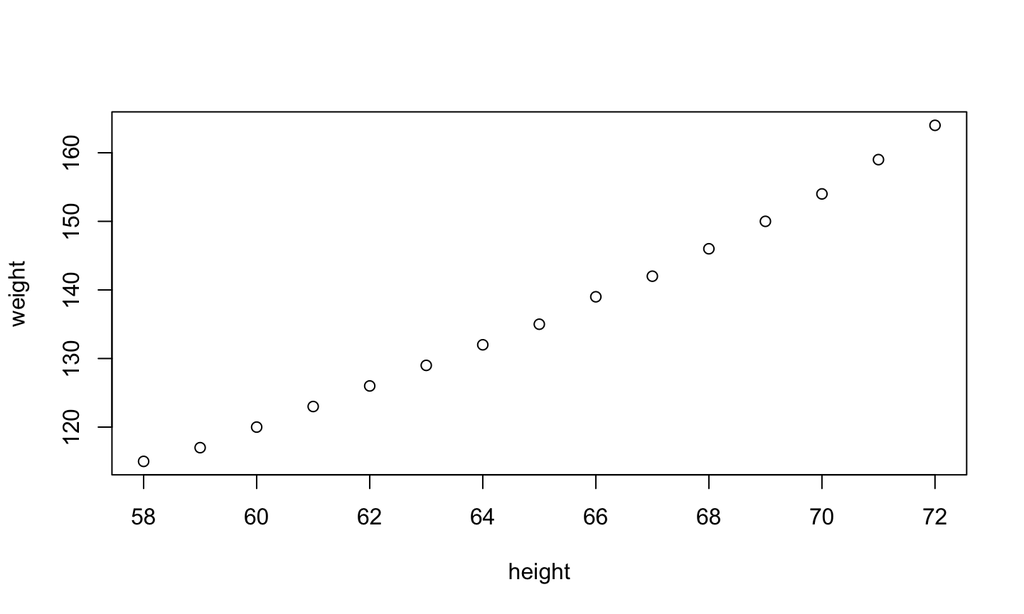

```r
plot(women)
```

```r
lm(weight ~ height, data = women)
```

```
##
## Call:
## lm(formula = weight ~ height, data = women)
##
## Coefficients:
## (Intercept)       height
##      -87.52         3.45
```

## Modelos

- Detalles de la regresión.

```r
m1 <- lm(weight ~ height, data = women)
summary(m1)
```

```
##
## Call:
## lm(formula = weight ~ height, data = women)
##
## Residuals:
##     Min      1Q  Median      3Q     Max
## -1.7333 -1.1333 -0.3833  0.7417  3.1167
##
## Coefficients:
##              Estimate Std. Error t value Pr(>|t|)
## (Intercept) -87.51667    5.93694  -14.74 1.71e-09 ***
## height        3.45000    0.09114   37.85 1.09e-14 ***
## ---
## Signif. codes:  0 '***' 0.001 '**' 0.01 '*' 0.05 '.' 0.1 ' ' 1
##
## Residual standard error: 1.525 on 13 degrees of freedom
## Multiple R-squared:  0.991,  Adjusted R-squared:  0.9903
## F-statistic:  1433 on 1 and 13 DF,  p-value: 1.091e-14
```

## Modelos

- Residuales ¿son homoscedásticos?

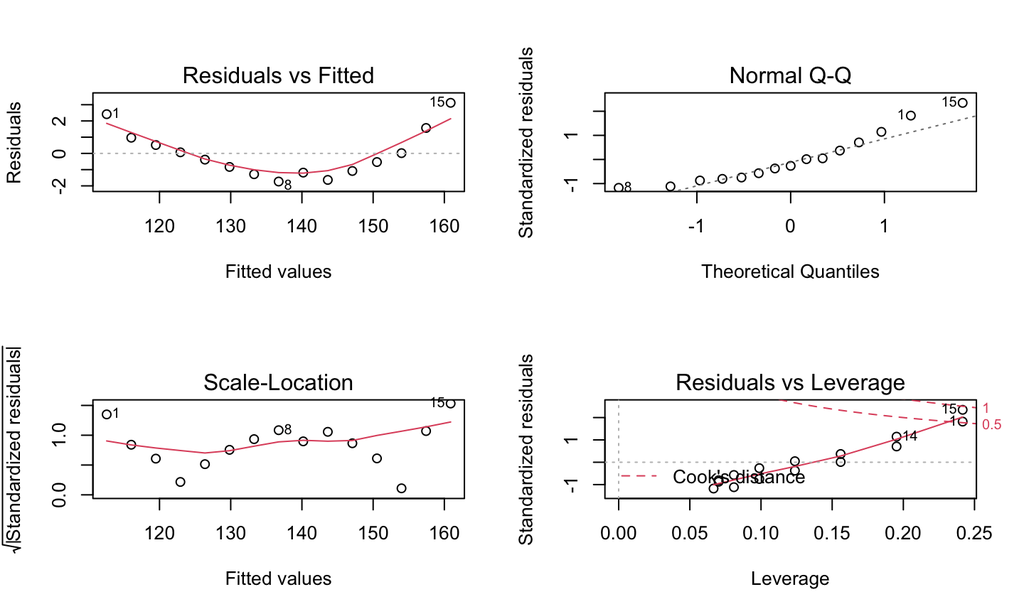

```r
par(mfrow = c(2, 2))
plot(m1)
```

## Modelos

[figure not shown]

## Modelos

- Regresión múltiple, la relación de más de una variable predictora y una variable de respuesta.

```r
movies <- read.table("movies.csv", sep = ",", header = T)
head(movies)
```

```
##   Ganancias CostoProd CostoPromo LibrosVendidos
## 1      85.1       8.5   5.100000            4.7
## 2     106.3      12.9   5.800000            8.8
## 3      50.2       5.2   2.100000           15.1
## 4     130.6      10.7   8.399999           12.2
## 5      54.8       3.1   2.900000           10.6
## 6      30.3       3.5   1.200000            3.5
```

```r
# Notoa: solicita a los facilitadores el conjunto de datos "movies.csv"
```

## Modelos

- 1 variable predictora.

```r
lm.mov1 <- lm(Ganancias ~ CostoProd, data = movies)
summary(lm.mov1)
```

```
##
## Call:
## lm(formula = Ganancias ~ CostoProd, data = movies)
##
## Residuals:
##     Min      1Q  Median      3Q     Max
## -13.136  -9.029  -3.689   3.208  29.723
##
## Coefficients:
##             Estimate Std. Error t value Pr(>|t|)
## (Intercept)   15.513     11.603   1.337 0.217989
## CostoProd      7.978      1.223   6.522 0.000184 ***
## ---
## Signif. codes:  0 '***' 0.001 '**' 0.01 '*' 0.05 '.' 0.1 ' ' 1
##
## Residual standard error: 14.26 on 8 degrees of freedom
## Multiple R-squared:  0.8417, Adjusted R-squared:  0.8219
## F-statistic: 42.54 on 1 and 8 DF,  p-value: 0.0001838
```

## Modelos

- 2 variables predictoras.

```r
lm.mov2 <- lm(Ganancias ~ CostoProd + CostoPromo, data = movies)
summary(lm.mov2)
```

```
##
## Call:
## lm(formula = Ganancias ~ CostoProd + CostoPromo, data = movies)
##
## Residuals:
##      Min       1Q   Median       3Q      Max
## -15.4168  -2.5696   0.8052   2.1200  11.0463
##
## Coefficients:
##             Estimate Std. Error t value Pr(>|t|)
## (Intercept)   11.848      6.765   1.751  0.12334
## CostoProd      4.228      1.153   3.667  0.00800 **
## CostoPromo     7.436      1.806   4.117  0.00448 **
## ---
## Signif. codes:  0 '***' 0.001 '**' 0.01 '*' 0.05 '.' 0.1 ' ' 1
##
## Residual standard error: 8.241 on 7 degrees of freedom
## Multiple R-squared:  0.9537, Adjusted R-squared:  0.9405
## F-statistic: 72.14 on 2 and 7 DF,  p-value: 2.131e-05
```

## Modelos

- 3 variables predictoras.

```r
lm.mov3 <- lm(Ganancias ~ CostoProd + CostoPromo + LibrosVendidos, data = movies)
summary(lm.mov3)
```

```
##
## Call:
## lm(formula = Ganancias ~ CostoProd + CostoPromo + LibrosVendidos,
##     data = movies)
##
## Residuals:
##      Min       1Q   Median       3Q      Max
## -12.4384  -3.1695   0.8499   3.5134   9.6207
##
## Coefficients:
##                Estimate Std. Error t value Pr(>|t|)
## (Intercept)      7.6760     6.7602   1.135   0.2995
## CostoProd        3.6616     1.1178   3.276   0.0169 *
## CostoPromo       7.6211     1.6573   4.598   0.0037 **
## LibrosVendidos   0.8285     0.5394   1.536   0.1754
## ---
## Signif. codes:  0 '***' 0.001 '**' 0.01 '*' 0.05 '.' 0.1 ' ' 1
##
## Residual standard error: 7.541 on 6 degrees of freedom
## Multiple R-squared:  0.9668, Adjusted R-squared:  0.9502
## F-statistic: 58.22 on 3 and 6 DF,  p-value: 7.913e-05
```

## Modelos

- Comparando el modelo 1 contra modelo 2.

```r
anova(lm.mov1, lm.mov2)
```

```
## Analysis of Variance Table
##
## Model 1: Ganancias ~ CostoProd
## Model 2: Ganancias ~ CostoProd + CostoPromo
##   Res.Df     RSS Df Sum of Sq      F   Pr(>F)
## 1      8 1626.27
## 2      7  475.37  1    1150.9 16.947 0.004478 **
## ---
## Signif. codes:  0 '***' 0.001 '**' 0.01 '*' 0.05 '.' 0.1 ' ' 1
```

## Modelos

- Comparando el modelo 2 contra modelo 3.

```r
anova(lm.mov2, lm.mov3)
```

```
## Analysis of Variance Table
##
## Model 1: Ganancias ~ CostoProd + CostoPromo
## Model 2: Ganancias ~ CostoProd + CostoPromo + LibrosVendidos
##   Res.Df    RSS Df Sum of Sq      F Pr(>F)
## 1      7 475.37
## 2      6 341.20  1    134.17 2.3594 0.1754
```

## Modelos: Ejercicios

- Usa `swiss` para realizar una regresión múltiple.
- Discute los parámetros obtenidos.

## Modelos: Ejercicios

- Solución (1era parte)
  - Disponible después de la fecha de entrega.

## Modelos: Ejercicios

- Solución (2nda parte)
  - Disponible después de la fecha de entrega.

## Modelos: Ejercicios

- Solución (3era parte)
  - Disponible después de la fecha de entrega.

## Modelos: Ejercicios

- Solución (3era parte)
  - Disponible después de la fecha de entrega.

## Modelos: Ejercicios

- Solución (3era parte)
  - Disponible después de la fecha de entrega.

## Modelos: Ejercicios

- Solución (4ta parte)
  - Disponible después de la fecha de entrega.

## Modelos Lineales Generalizados (GLM)

## Modelos Lineales Generalizados

- Combinan variables predictoras discretas y continuas.
- Podemos especifcar la naturaleza de la variable de respuesta mediante una función liga (por ejemplo: Gausiana, Poisson o Binomial).
- Cuando la variable de respuesta es binomial, también se conoce como *Regresión Logística*.

## Modelos Lineales Generalizados

- 1 variable continua.

```r
?Puromycin
head(Puromycin)
```

```r
pmycin_glm <- glm(rate ~ conc, data = Puromycin)
summary(pmycin_glm)
```

```
##
## Call:
## glm(formula = rate ~ conc, data = Puromycin)
##
## Deviance Residuals:
##     Min       1Q   Median       3Q      Max
## -49.861  -15.247   -2.861   15.686   48.054
##
## Coefficients:
##             Estimate Std. Error t value Pr(>|t|)
## (Intercept)    93.92       8.00   11.74 1.09e-10 ***
## conc          105.40      16.92    6.23 3.53e-06 ***
## ---
## Signif. codes:  0 '***' 0.001 '**' 0.01 '*' 0.05 '.' 0.1 ' ' 1
##
## (Dispersion parameter for gaussian family taken to be 830.4261)
##
##     Null deviance: 49665  on 22  degrees of freedom
## Residual deviance: 17439  on 21  degrees of freedom
## AIC: 223.78
##
## Number of Fisher Scoring iterations: 2
```

## Modelos Lineales Generalizados

- 1 variable continua.

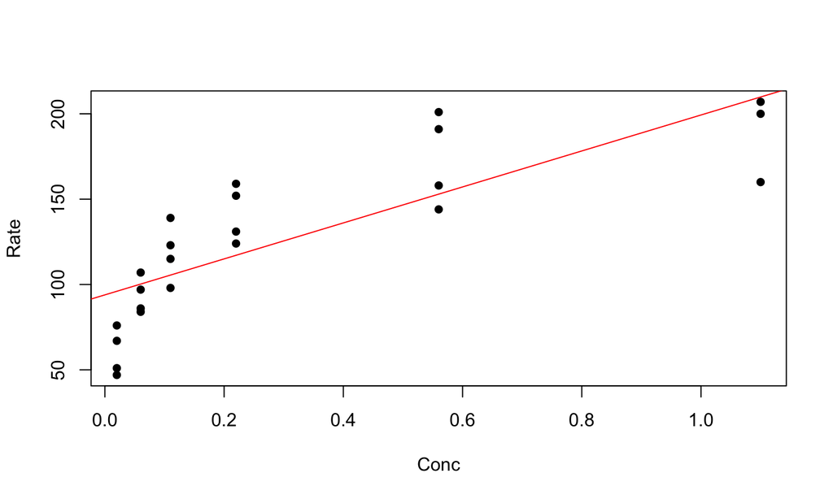

```r
plot(Puromycin$conc, Puromycin$rate, pch = 16, xlab = "Conc", ylab = "Rate")
abline(lm(rate ~ conc, data = Puromycin), col = "red")
```

## Modelos Lineales Generalizados

- 1 una variable discreta.

```r
pmycin_glm <- glm(rate ~ state, data = Puromycin)
summary(pmycin_glm)
```

```
##
## Call:
## glm(formula = rate ~ state, data = Puromycin)
##
## Deviance Residuals:
##     Min       1Q   Median       3Q      Max
## -94.583  -30.655    4.273   40.273   65.417
##
## Coefficients:
##                Estimate Std. Error t value Pr(>|t|)
## (Intercept)      141.58      13.24  10.690 5.94e-10 ***
## stateuntreated   -30.86      19.15  -1.611    0.122
## ---
## Signif. codes:  0 '***' 0.001 '**' 0.01 '*' 0.05 '.' 0.1 ' ' 1
##
## (Dispersion parameter for gaussian family taken to be 2104.814)
##
##     Null deviance: 49665  on 22  degrees of freedom
## Residual deviance: 44201  on 21  degrees of freedom
## AIC: 245.17
##
## Number of Fisher Scoring iterations: 2
```

## Modelos Lineales Generalizados

- 1 una variable discreta.

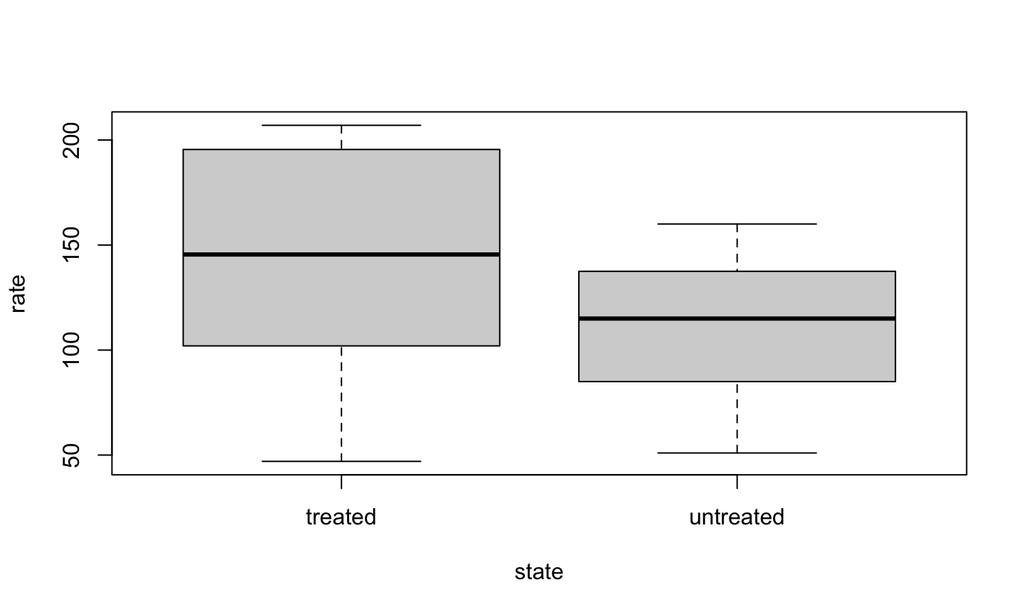

```r
boxplot(rate ~ state, data = Puromycin)
```

## Modelos Lineales Generalizados

- 2 variables e interacción.

```r
pmycin_glm <- glm(conc ~ rate*state, data = Puromycin)
summary(pmycin_glm)
```

```
##
## Call:
## glm(formula = conc ~ rate * state, data = Puromycin)
##
## Deviance Residuals:
##      Min        1Q    Median        3Q       Max
## -0.23393  -0.15653  -0.06870   0.07926   0.45212
##
## Coefficients:
##                      Estimate Std. Error t value Pr(>|t|)
## (Intercept)         -0.540523   0.187185  -2.888  0.00943 **
## rate                 0.006254   0.001245   5.025 7.52e-05 ***
## stateuntreated      -0.017989   0.288642  -0.062  0.95096
## rate:stateuntreated  0.001285   0.002265   0.567  0.57706
## ---
## Signif. codes:  0 '***' 0.001 '**' 0.01 '*' 0.05 '.' 0.1 ' ' 1
##
## (Dispersion parameter for gaussian family taken to be 0.04780568)
##
##     Null deviance: 2.90099  on 22  degrees of freedom
## Residual deviance: 0.90831  on 19  degrees of freedom
## AIC: 0.94285
##
## Number of Fisher Scoring iterations: 2
```

## Modelos Lineales Generalizados

- 2 variables e interacción.

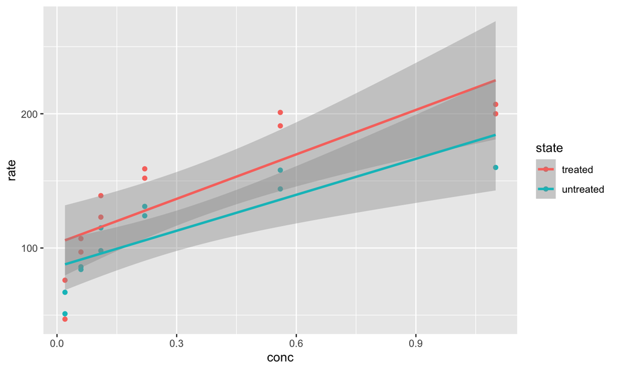

```r
ggplot(Puromycin, aes(x=conc, y=rate, color=state)) + geom_point() + geom_smooth(method='lm')
```

## Modelos Lineales Generalizados

- Función liga.

```r
?infert
```

```r
head(infert)
```

```
##   education age parity induced case spontaneous stratum pooled.stratum
## 1    0-5yrs  26      6       1    1           2       1              3
## 2    0-5yrs  42      1       1    1           0       2              1
## 3    0-5yrs  39      6       2    1           0       3              4
## 4    0-5yrs  34      4       2    1           0       4              2
## 5   6-11yrs  35      3       1    1           1       5             32
## 6   6-11yrs  36      4       2    1           1       6             36
```

```r
unique(infert$case)
```

```
## [1] 1 0
```

## Modelos Lineales Generalizados

- Función liga.

```r
inf.bn <- glm(case ~ age + parity + education + spontaneous,
    data = infert, family = binomial())
summary(inf.bn)
```

```
##
## Call:
## glm(formula = case ~ age + parity + education + spontaneous,
##     family = binomial(), data = infert)
##
## Deviance Residuals:
##     Min       1Q   Median       3Q      Max
## -1.7219  -0.7698  -0.6353   0.9825   2.1823
##
## Coefficients:
##                  Estimate Std. Error z value Pr(>|z|)
## (Intercept)      -0.63833    1.33256  -0.479   0.6319
## age               0.01553    0.02920   0.532   0.5947
## parity           -0.30516    0.13729  -2.223   0.0262 *
## education6-11yrs -0.69194    0.76038  -0.910   0.3628
## education12+ yrs -0.84472    0.79294  -1.065   0.2867
## spontaneous       1.27783    0.22305   5.729 1.01e-08 ***
## ---
## Signif. codes:  0 '***' 0.001 '**' 0.01 '*' 0.05 '.' 0.1 ' ' 1
##
## (Dispersion parameter for binomial family taken to be 1)
##
##     Null deviance: 316.17  on 247  degrees of freedom
## Residual deviance: 278.26  on 242  degrees of freedom
## AIC: 290.26
##
## Number of Fisher Scoring iterations: 4
```

## Modelos Lineales Generalizados

- Función liga.

```r
inf.no <- glm(case ~ age + parity + education + spontaneous,
    data = infert)
summary(inf.no)
```

```
##
## Call:
## glm(formula = case ~ age + parity + education + spontaneous,
##     data = infert)
##
## Deviance Residuals:
##     Min       1Q   Median       3Q      Max
## -0.7752  -0.2685  -0.1795   0.3808   0.9700
##
## Coefficients:
##                   Estimate Std. Error t value Pr(>|t|)
## (Intercept)       0.371789   0.258916   1.436   0.1523
## age               0.002873   0.005664   0.507   0.6124
## parity           -0.059536   0.026263  -2.267   0.0243 *
## education6-11yrs -0.155096   0.146016  -1.062   0.2892
## education12+ yrs -0.181238   0.151961  -1.193   0.2342
## spontaneous       0.271910   0.041317   6.581 2.87e-10 ***
## ---
## Signif. codes:  0 '***' 0.001 '**' 0.01 '*' 0.05 '.' 0.1 ' ' 1
##
## (Dispersion parameter for gaussian family taken to be 0.1935233)
##
##     Null deviance: 55.222  on 247  degrees of freedom
## Residual deviance: 46.833  on 242  degrees of freedom
## AIC: 304.42
##
## Number of Fisher Scoring iterations: 2
```

## Modelos Lineales Generalizados

- Comparación binomial.

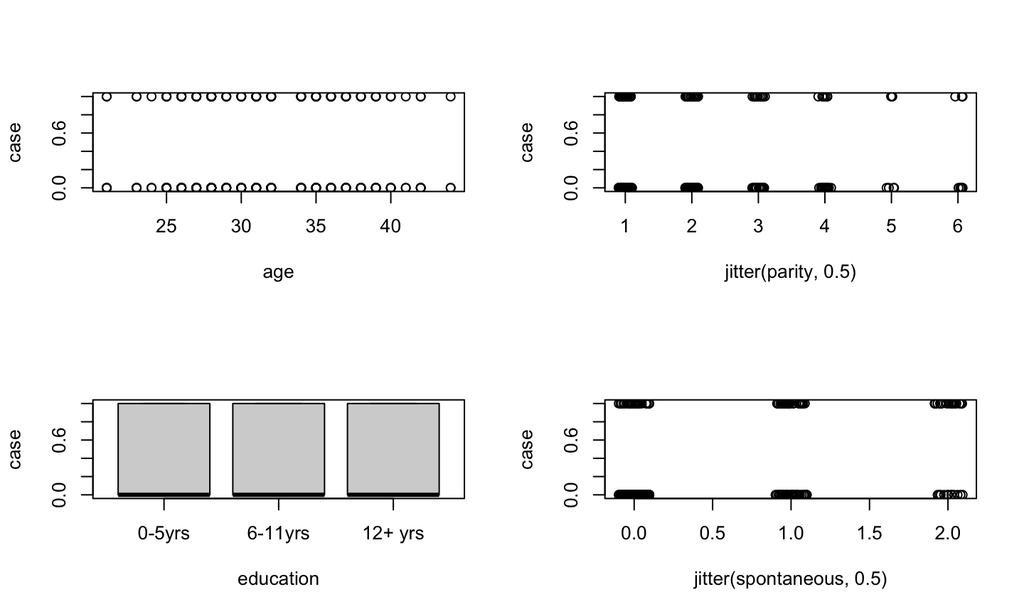

```r
par(mfrow=c(2,2))
with(infert, plot(case ~ age + jitter(parity,.5) + education + jitter(spontaneous,.5)))
```

## Modelos Lineales Generalizados

- Comparación *post hoc*.

```r
library(multcomp)
```

```r
summary(glht(inf.no, mcp(education="Tukey")))
```

```
##
##   Simultaneous Tests for General Linear Hypotheses
##
## Multiple Comparisons of Means: Tukey Contrasts
##
##
## Fit: glm(formula = case ~ age + parity + education + spontaneous,
##     data = infert)
##
## Linear Hypotheses:
##                        Estimate Std. Error z value Pr(>|z|)
## 6-11yrs - 0-5yrs == 0  -0.15510    0.14602  -1.062    0.519
## 12+ yrs - 0-5yrs == 0  -0.18124    0.15196  -1.193    0.438
## 12+ yrs - 6-11yrs == 0 -0.02614    0.06043  -0.433    0.896
## (Adjusted p values reported -- single-step method)
```

## GLM: Ejercicios

- Usa `hsb` del paquete `descriptr` para hacer un modelo para cada variable de respuesta: `read`, `write`, `math`, `science`, `socst`.
- Calcula el puntaje general (como suma y como promedio) y haz un nuevo modelo utilizando esta nueva variable de respuesta.
- Encuentra el “mejor” modelo.
- Grafica las comparaciones para las que salgan significativas.

## GLM: Ejercicios

- Solución (1era parte)
  - Disponibles después de la fecha de entrega.

## GLM: Ejercicios

- Solución (2nda parte)
  - Disponibles después de la fecha de entrega.

## GLM: Ejercicios

- Solución (3era parte)
  - Disponibles después de la fecha de entrega.

## GLM: Ejercicios

- Solución (4ta parte)
  - Disponibles después de la fecha de entrega.

## GLM: Ejercicios

- Solución (5ta parte)
  - Disponibles después de la fecha de entrega.

## GLM: Ejercicios

- Solución (6ta parte)
  - Disponibles después de la fecha de entrega.

## Modelos Lineales Generalizados Mixtos (GLMM)

## Modelos Lineales Generalizados Mixtos

- Múltiples variables predictoras (categóricas y numéricas) sobre una variable de respuesta.
- Evaluar datos en los que existen **medidas repetidas**.
- Contemplan el error intra grupo, por ejemplo, para observaciones temporales sobre el mismo individuo (antes y después) o sobre distintos individuos en la misma circunstancia ( lugar, hora o fecha).

## Modelos Lineales Generalizados Mixtos

```r
library(lmerTest)
?iris
head(iris)
```

```
##   Sepal.Length Sepal.Width Petal.Length Petal.Width Species
## 1          5.1         3.5          1.4         0.2  setosa
## 2          4.9         3.0          1.4         0.2  setosa
## 3          4.7         3.2          1.3         0.2  setosa
## 4          4.6         3.1          1.5         0.2  setosa
## 5          5.0         3.6          1.4         0.2  setosa
## 6          5.4         3.9          1.7         0.4  setosa
```

## Modelos Lineales Generalizados Mixtos

- Cómo incluir el *random effect* (efecto aleatorio)

```r
lmm1<-lmer(Sepal.Length ~ Petal.Length + (1|Species), data = iris)
summary(lmm1)
```

```
## Linear mixed model fit by REML. t-tests use Satterthwaite's method [
## lmerModLmerTest]
## Formula: Sepal.Length ~ Petal.Length + (1 | Species)
##    Data: iris
##
## REML criterion at convergence: 119.8
##
## Scaled residuals:
##      Min       1Q   Median       3Q      Max
## -2.23334 -0.67332 -0.01684  0.67680  3.04429
##
## Random effects:
##  Groups   Name        Variance Std.Dev.
##  Species  (Intercept) 1.1617   1.0778
##  Residual             0.1143   0.3381
## Number of obs: 150, groups:  Species, 3
##
## Fixed effects:
##               Estimate Std. Error        df t value Pr(>|t|)
## (Intercept)    2.50446    0.66743   2.45496   3.752   0.0463 *
## Petal.Length   0.88847    0.06379 144.56089  13.927   <2e-16 ***
## ---
## Signif. codes:  0 '***' 0.001 '**' 0.01 '*' 0.05 '.' 0.1 ' ' 1
##
## Correlation of Fixed Effects:
##             (Intr)
## Petal.Lngth -0.359
```

## Modelos Lineales Generalizados Mixtos

- Resultados

```r
anova(lmm1)
```

```
## Type III Analysis of Variance Table with Satterthwaite's method
##              Sum Sq Mean Sq NumDF  DenDF F value    Pr(>F)
## Petal.Length 22.166  22.166     1 144.56  193.96 < 2.2e-16 ***
## ---
## Signif. codes:  0 '***' 0.001 '**' 0.01 '*' 0.05 '.' 0.1 ' ' 1
```

## Modelos Lineales Generalizados Mixtos

- Visualización

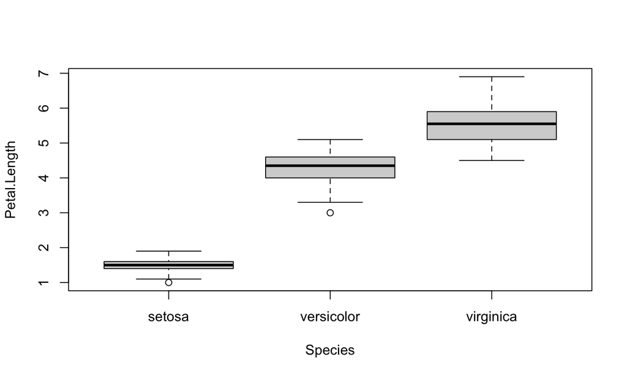

```r
boxplot(Petal.Length ~ Species, data = iris)
```

## GLMM: Ejercicios

- Revisa cómo están organizados los datos con `head()`, `levels()` y `str()`.
- Construye un diagrama (a mano) del diseño experimental que sugieren los datos.
- Usa el conjunto de datos `CO2` para hacer un modelo donde consideres `Type`, `Plant` y `Treatment` como efectos aleatorios *anidados* (separados por `/`).
- Grafica `uptake` por cada una de las variables significativas.

## GLMM: Ejercicios

- Solución (1er parte)
  - Disponible después de la fecha de entrega.

## GLMM: Ejercicios

- Solución (2nda parte)
  - Disponible después de la fecha de entrega.

## GLMM: Ejercicios

- Solución (3era parte)
  - Disponible después de la fecha de entrega.

## GLMM: Ejercicios

- Solución (4ta parte)
  - Disponible después de la fecha de entrega.

## Análisis agregativos

## Componentes principales

- ¿Cuál es la función de un análisis de componentes principales (PCA)?
- Reducir el número de variables al identificar áquellas que nos dan información redundante o agrupar variables dentro de una categoría más amplia.
- Combinar ambos análisis (por individuos y por variables) para caracterizar grupos de individuos por variables.

## Componentes principales

```r
install.packages("FactoMineR")
library(FactoMineR) # Es un paquete de muchos disponibles
?decathlon
```

```r
data(decathlon)
head(decathlon)
```

```
##          100m Long.jump Shot.put High.jump  400m 110m.hurdle Discus Pole.vault
## SEBRLE  11.04      7.58    14.83      2.07 49.81       14.69  43.75       5.02
## CLAY    10.76      7.40    14.26      1.86 49.37       14.05  50.72       4.92
## KARPOV  11.02      7.30    14.77      2.04 48.37       14.09  48.95       4.92
## BERNARD 11.02      7.23    14.25      1.92 48.93       14.99  40.87       5.32
## YURKOV  11.34      7.09    15.19      2.10 50.42       15.31  46.26       4.72
## WARNERS 11.11      7.60    14.31      1.98 48.68       14.23  41.10       4.92
##         Javeline 1500m Rank Points Competition
## SEBRLE     63.19 291.7    1   8217    Decastar
## CLAY       60.15 301.5    2   8122    Decastar
## KARPOV     50.31 300.2    3   8099    Decastar
## BERNARD    62.77 280.1    4   8067    Decastar
## YURKOV     63.44 276.4    5   8036    Decastar
## WARNERS    51.77 278.1    6   8030    Decastar
```

## Componentes principales

- Preguntas para un PCA
- ¿Cómo se agrupan los sujetos?
  - ¿Qué ejes describen mejor los agrupamientos de atletas con desempeños similares?
- ¿Cómo se agrupan las variables?
  - ¿Qué ejes describen mejor los agrupamientos de variables similares?

## Componentes principales

```r
res.pca <- PCA(decathlon[ ,1:10], scale.unit=TRUE , ncp=5, graph=F)
str(res.pca)
```

```
## List of 5
##  $ eig : num [1:10, 1:3] 3.272 1.737 1.405 1.057 0.685 ...
##   ..- attr(*, "dimnames")=List of 2
##   .. ..$ : chr [1:10] "comp 1" "comp 2" "comp 3" "comp 4" ...
##   .. ..$ : chr [1:3] "eigenvalue" "percentage of variance" "cumulative percentage of variance"
##  $ var :List of 4
##   ..$ coord  : num [1:10, 1:5] -0.775 0.742 0.623 0.572 -0.68 ...
##   .. ..- attr(*, "dimnames")=List of 2
##   .. .. ..$ : chr [1:10] "100m" "Long.jump" "Shot.put" "High.jump" ...
##   .. .. ..$ : chr [1:5] "Dim.1" "Dim.2" "Dim.3" "Dim.4" ...
##   ..$ cor    : num [1:10, 1:5] -0.775 0.742 0.623 0.572 -0.68 ...
##   .. ..- attr(*, "dimnames")=List of 2
##   .. .. ..$ : chr [1:10] "100m" "Long.jump" "Shot.put" "High.jump" ...
##   .. .. ..$ : chr [1:5] "Dim.1" "Dim.2" "Dim.3" "Dim.4" ...
##   ..$ cos2   : num [1:10, 1:5] 0.6 0.55 0.388 0.327 0.462 ...
##   .. ..- attr(*, "dimnames")=List of 2
##   .. .. ..$ : chr [1:10] "100m" "Long.jump" "Shot.put" "High.jump" ...
##   .. .. ..$ : chr [1:5] "Dim.1" "Dim.2" "Dim.3" "Dim.4" ...
##   ..$ contrib: num [1:10, 1:5] 18.3 16.8 11.8 10 14.1 ...
##   .. ..- attr(*, "dimnames")=List of 2
##   .. .. ..$ : chr [1:10] "100m" "Long.jump" "Shot.put" "High.jump" ...
##   .. .. ..$ : chr [1:5] "Dim.1" "Dim.2" "Dim.3" "Dim.4" ...
##  $ ind :List of 4
##   ..$ coord  : num [1:41, 1:5] 0.792 1.235 1.358 -0.61 -0.586 ...
##   .. ..- attr(*, "dimnames")=List of 2
##   .. .. ..$ : chr [1:41] "SEBRLE" "CLAY" "KARPOV" "BERNARD" ...
##   .. .. ..$ : chr [1:5] "Dim.1" "Dim.2" "Dim.3" "Dim.4" ...
##   ..$ cos2   : num [1:41, 1:5] 0.1117 0.124 0.1599 0.0487 0.0377 ...
##   .. ..- attr(*, "dimnames")=List of 2
##   .. .. ..$ : chr [1:41] "SEBRLE" "CLAY" "KARPOV" "BERNARD" ...
##   .. .. ..$ : chr [1:5] "Dim.1" "Dim.2" "Dim.3" "Dim.4" ...
##   ..$ contrib: num [1:41, 1:5] 0.467 1.137 1.375 0.277 0.256 ...
##   .. ..- attr(*, "dimnames")=List of 2
##   .. .. ..$ : chr [1:41] "SEBRLE" "CLAY" "KARPOV" "BERNARD" ...
##   .. .. ..$ : chr [1:5] "Dim.1" "Dim.2" "Dim.3" "Dim.4" ...
##   ..$ dist   : Named num [1:41] 2.37 3.51 3.4 2.76 3.02 ...
##   .. ..- attr(*, "names")= chr [1:41] "SEBRLE" "CLAY" "KARPOV" "BERNARD" ...
##  $ svd :List of 3
##   ..$ vs: num [1:10] 1.809 1.318 1.185 1.028 0.828 ...
##   ..$ U : num [1:41, 1:5] 0.438 0.683 0.751 -0.337 -0.324 ...
##   ..$ V : num [1:10, 1:5] -0.428 0.41 0.344 0.316 -0.376 ...
##  $ call:List of 9
##   ..$ row.w     : num [1:41] 0.0244 0.0244 0.0244 0.0244 0.0244 ...
##   ..$ col.w     : num [1:10] 1 1 1 1 1 1 1 1 1 1
##   ..$ scale.unit: logi TRUE
##   ..$ ncp       : num 5
##   ..$ centre    : num [1:10] 11 7.26 14.48 1.98 49.62 ...
##   ..$ ecart.type: num [1:10] 0.2598 0.3125 0.8143 0.0879 1.1393 ...
##   ..$ X         :'data.frame':   41 obs. of  10 variables:
##   .. ..$ 100m       : num [1:41] 11 10.8 11 11 11.3 ...
##   .. ..$ Long.jump  : num [1:41] 7.58 7.4 7.3 7.23 7.09 7.6 7.3 7.31 6.81 7.56 ...
##   .. ..$ Shot.put   : num [1:41] 14.8 14.3 14.8 14.2 15.2 ...
##   .. ..$ High.jump  : num [1:41] 2.07 1.86 2.04 1.92 2.1 1.98 2.01 2.13 1.95 1.86 ...
##   .. ..$ 400m       : num [1:41] 49.8 49.4 48.4 48.9 50.4 ...
##   .. ..$ 110m.hurdle: num [1:41] 14.7 14.1 14.1 15 15.3 ...
##   .. ..$ Discus     : num [1:41] 43.8 50.7 49 40.9 46.3 ...
##   .. ..$ Pole.vault : num [1:41] 5.02 4.92 4.92 5.32 4.72 4.92 4.42 4.42 4.92 4.82 ...
##   .. ..$ Javeline   : num [1:41] 63.2 60.1 50.3 62.8 63.4 ...
##   .. ..$ 1500m      : num [1:41] 292 302 300 280 276 ...
##   ..$ row.w.init: num [1:41] 1 1 1 1 1 1 1 1 1 1 ...
##   ..$ call      : language PCA(X = decathlon[, 1:10], scale.unit = TRUE, ncp = 5, graph = F)
##  - attr(*, "class")= chr [1:2] "PCA" "list "
```

## Componentes principales

```r
eig.val <- get_eigenvalue(res.pca)
eig.val
```

```
##        eigenvalue variance.percent cumulative.variance.percent
## Dim.1   3.2719055        32.719055                    32.71906
## Dim.2   1.7371310        17.371310                    50.09037
## Dim.3   1.4049167        14.049167                    64.13953
## Dim.4   1.0568504        10.568504                    74.70804
## Dim.5   0.6847735         6.847735                    81.55577
## Dim.6   0.5992687         5.992687                    87.54846
## Dim.7   0.4512353         4.512353                    92.06081
## Dim.8   0.3968766         3.968766                    96.02958
## Dim.9   0.2148149         2.148149                    98.17773
## Dim.10  0.1822275         1.822275                   100.00000
```

## Componentes principales

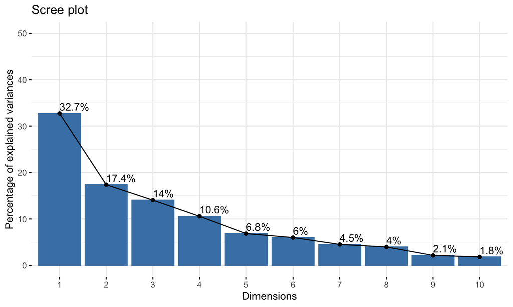

```r
fviz_eig(res.pca, addlabels = TRUE, ylim = c(0, 50))
```

## Componentes principales

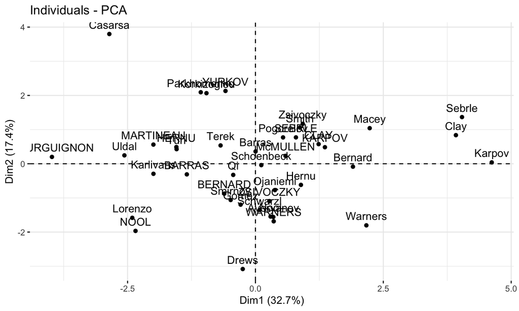

```r
fviz_pca_ind(res.pca)
```

## Componentes principales

- Individuos más extremos en Dim1: BOURGUIGNON contra Karpov.

```r
names <- c("BOURGUIGNON", "Karpov")
decathlon[row.names(decathlon) %in% names, ]
```

```
##              100m Long.jump Shot.put High.jump  400m 110m.hurdle Discus
## BOURGUIGNON 11.36      6.80    13.46      1.86 51.16       15.67  40.49
## Karpov      10.50      7.81    15.93      2.09 46.81       13.97  51.65
##             Pole.vault Javeline  1500m Rank Points Competition
## BOURGUIGNON       5.02    54.68 291.70   13   7313    Decastar
## Karpov            4.60    55.54 278.11    3   8725    OlympicG
```

## Componentes principales

```r
names <- c("YURKOV", "Drews")
decathlon[row.names(decathlon) %in% names, ]
```

```
##         100m Long.jump Shot.put High.jump  400m 110m.hurdle Discus Pole.vault
## YURKOV 11.34      7.09    15.19      2.10 50.42       15.31  46.26       4.72
## Drews  10.87      7.38    13.07      1.88 48.51       14.01  40.11       5.00
##        Javeline  1500m Rank Points Competition
## YURKOV    63.44 276.40    5   8036    Decastar
## Drews     51.53 274.21   19   7926    OlympicG
```

## Componentes principales

- Podemos trazar 4 divisiones, rápidos y fuertes (*Sebrle*), lentos (*Casarsa*), rápidos y débiles (*Warners*) y lentos y débiles (*Lorenzo*).

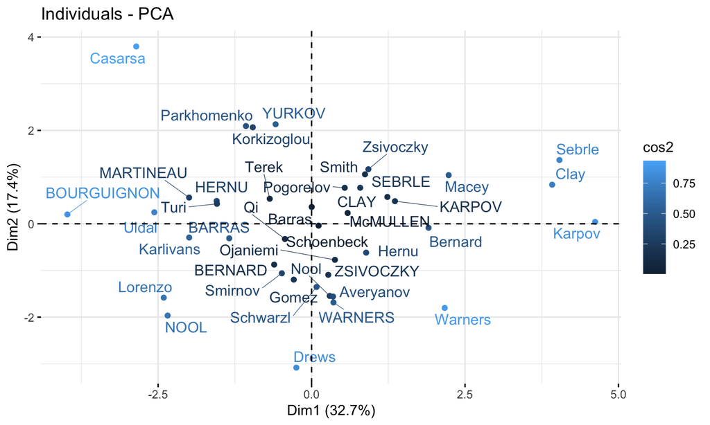

```r
fviz_pca_ind(res.pca, col.ind = "cos2", repel = TRUE)
```

## Componentes principales

- Las variables `Discus`, `Shot.put` y `High.jump` no tienen mucha correlación con `X100m`, `X400m`, `X110m.hurdle` y `Long.jump`.

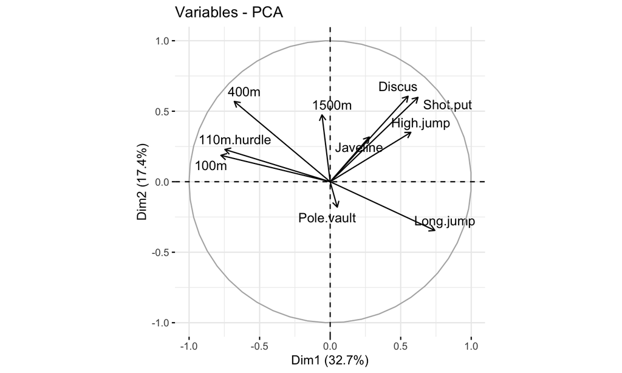

```r
fviz_pca_var(res.pca, repel = TRUE)
```

http://www.sthda.com/english/articles/31-principal-component-methods-in-r-practical-guide/112-pca-principal-component-analysis-essentials/

## Componentes principales: Ejercicios

- Construye un PCA con `data(wine)`.
- Obtén:
  - Las gráficas de los individuos y de las variables.
  - Los *valores eigen* (>1) y el porcentaje de explicación de las dimensiones.
  - El *scree plot*.
- ¿Quiénes son los individuos más extremos?
- ¿Cómo definirías las dimensiones (en tus propios términos)?

## Componentes principales: Ejercicios

- Solución (1era parte)
  - Disponible después de la fecha de entrega.

## Componentes principales: Ejercicios

- Solución (2nda parte)
  - Disponible después de la fecha de entrega.

## Componentes principales: Ejercicios

- Solución (3ra parte)
  - Disponible después de la fecha de entrega.

## Componentes principales: Ejercicios

- Solución (4ta parte)
  - Disponible después de la fecha de entrega.

## Componentes principales: Ejercicios

- Solución (5ta parte)
  - Disponible después de la fecha de entrega.

## Componentes principales: Ejercicios

- Solución (6ta parte)
  - Disponible después de la fecha de entrega.

## Componentes principales: Ejercicios

- Solución (7ma parte)
  - Disponible después de la fecha de entrega.

## Clustering

- Una técnica de clasificar una serie de datos en grupos.

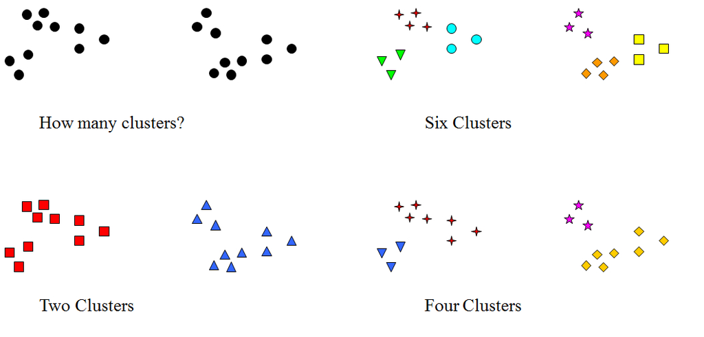

## Clustering: `kmeans`

- Uno de los métodos más viejos de agregación.
- Se eligen el número de clusters que uno cree que hay en los datos (`k`).
- El algoritmo elige k puntos al azar y calcula la distancia a todos los puntos. Las observaciones se clasifican en “agregados”.
- Se recalculan los centros y se vuelve a comenzar.
- El proceso continua hasta que las observaciones no cambian de grupo.

## Clustering: `kmeans`

```r
iris.kc <- kmeans(iris[1:4],3)
print(iris.kc)
```

```
## K-means clustering with 3 clusters of sizes 62, 38, 50
##
## Cluster means:
##   Sepal.Length Sepal.Width Petal.Length Petal.Width
## 1     5.901613    2.748387     4.393548    1.433871
## 2     6.850000    3.073684     5.742105    2.071053
## 3     5.006000    3.428000     1.462000    0.246000
##
## Clustering vector:
##   [1] 3 3 3 3 3 3 3 3 3 3 3 3 3 3 3 3 3 3 3 3 3 3 3 3 3 3 3 3 3 3 3 3 3 3 3 3 3
##  [38] 3 3 3 3 3 3 3 3 3 3 3 3 3 1 1 2 1 1 1 1 1 1 1 1 1 1 1 1 1 1 1 1 1 1 1 1 1
##  [75] 1 1 1 2 1 1 1 1 1 1 1 1 1 1 1 1 1 1 1 1 1 1 1 1 1 1 2 1 2 2 2 2 1 2 2 2 2
## [112] 2 2 1 1 2 2 2 2 1 2 1 2 1 2 2 1 1 2 2 2 2 2 1 2 2 2 2 1 2 2 2 1 2 2 2 1 2
## [149] 2 1
##
## Within cluster sum of squares by cluster:
## [1] 39.82097 23.87947 15.15100
##  (between_SS / total_SS =  88.4 %)
##
## Available components:
##
## [1] "cluster"      "centers"      "totss"        "withinss"     "tot.withinss"
## [6] "betweenss"    "size"         "iter"         "ifault"
```

```r
table(iris$Species, iris.kc$cluster)
```

```
##
##               1  2  3
##   setosa      0  0 50
##   versicolor 48  2  0
##   virginica  14 36  0
```

## Clustering: `kmeans`

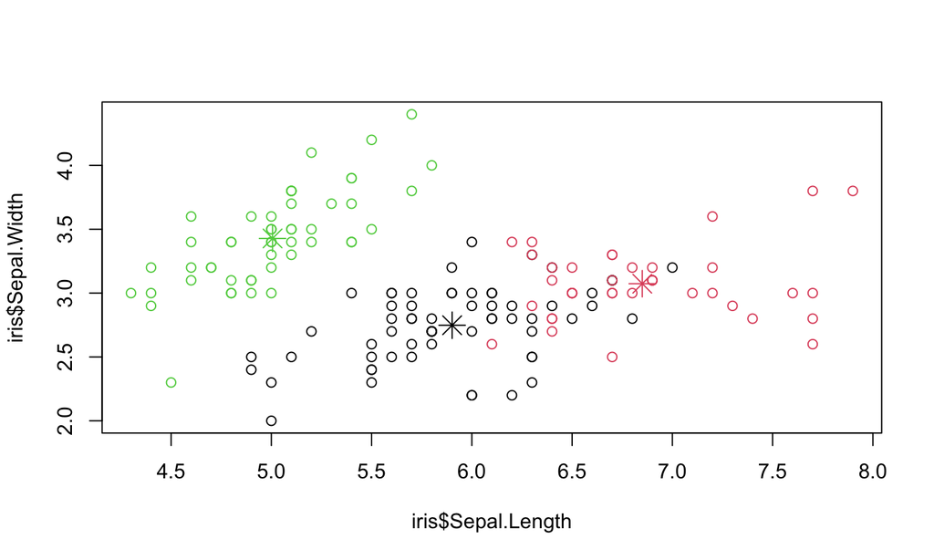

```r
plot(iris$Sepal.Length, iris$Sepal.Width, col=iris.kc$cluster)
points(iris.kc$centers[, c("Sepal.Length", "Sepal.Width")], col=1:3, pch=8, cex=2)
```

## Clustering: `pam`

- Una alternativa más moderna de agregación es PAM (*Partición Alrededor de Medias*).
- Al igual que en `kmeans`, es necesario especificar el número estimado de clusters.
- Este algoritmo recalcula las distancias entre los objeto dentro de un cluster en cada ciclo, lo que puede dar como resultado clústers más robustos.
- Como `kmeans`, el resultado puede cambiar al cambiar `k`.

## Clustering: `pam`

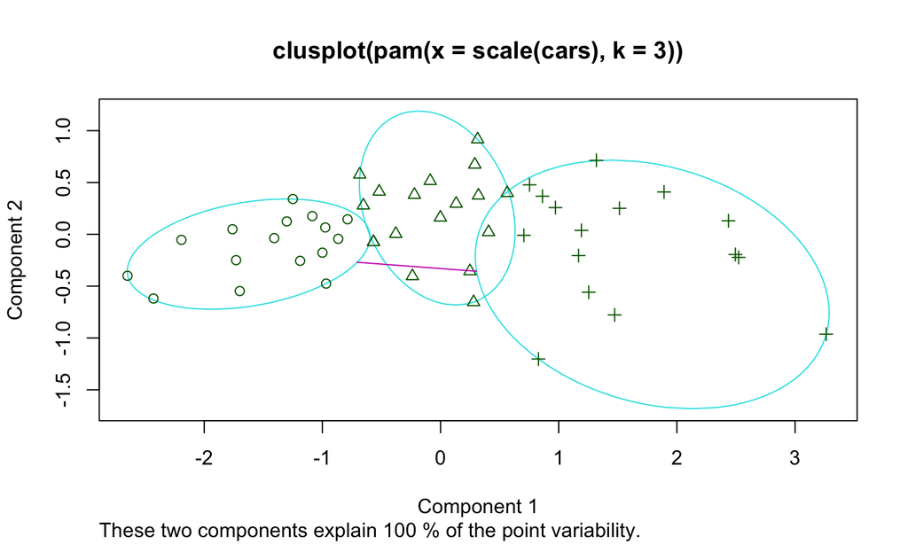

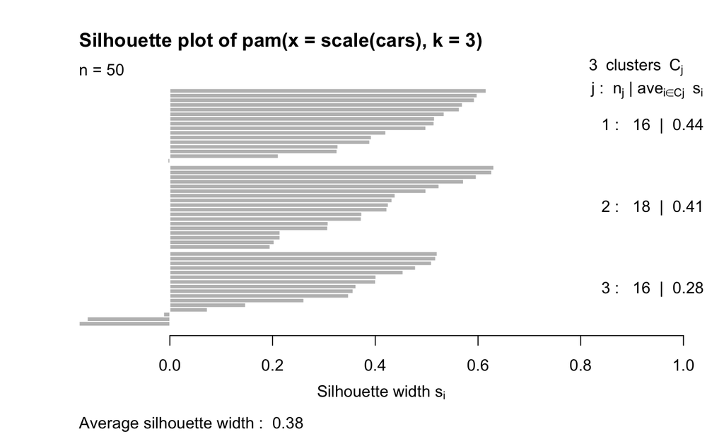

```r
library(cluster)
cars.clus <- pam(scale(cars), k = 3)
plot(cars.clus)
```

## Clustering: `pam`

- El gráfico de siluetas produce una medida para cada valor que nos dice que también encaja en el clúster.
- Valores cerca de 1 indican un buen ajuste, mientras que valores cerca de 0 o negativos indican que ese caso probablemente pertenezca a otro clúster.
- En cada clúster, los valores están organizados de mayor a menor.
- Criterios para elegir el número de clústers o a saber si el algoritmo está haciendo un buen trabajo.

## Clustering: `hclust`

- Cómo se agregan más puntos a ese clúster inicial puede depender del método: distancia mínima, máxima, promedio, etc.
- Cada uno de estos métodos puede mostrar distintos aspectos de la estructura de los datos.
- Usar la distancia al punto mínimo genera dendogramas tipo “serpiente”.
- Usar la distancia al punto máximo genera grupos más chicos y densos.
- Usar el promedio es un compromiso entre estos dos puntos.
- El método de Ward intenta usar distancia mínima, pero que no queden grupos demasiado pequeños.

## Clustering: `hclust`

- Un aspecto que hace a este algoritmo interesante es que las soluciones con muchos clústers están incluidas (anidadas) dentro de las soluciones con menos grupos.
- Esto hace que las observaciones no salten de un grupo a otro como lo hacen en `kmeans` o `pam`.
- Tampoco es necesario especificar el número de grupos.

## Clustering: `hclust`

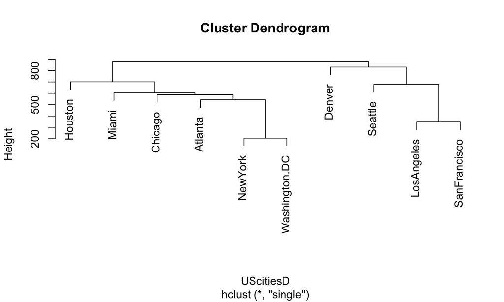

```r
uscities.single.link <- hclust(UScitiesD, method = "single")
plot(uscities.single.link)
```

## Clustering: `hclust`

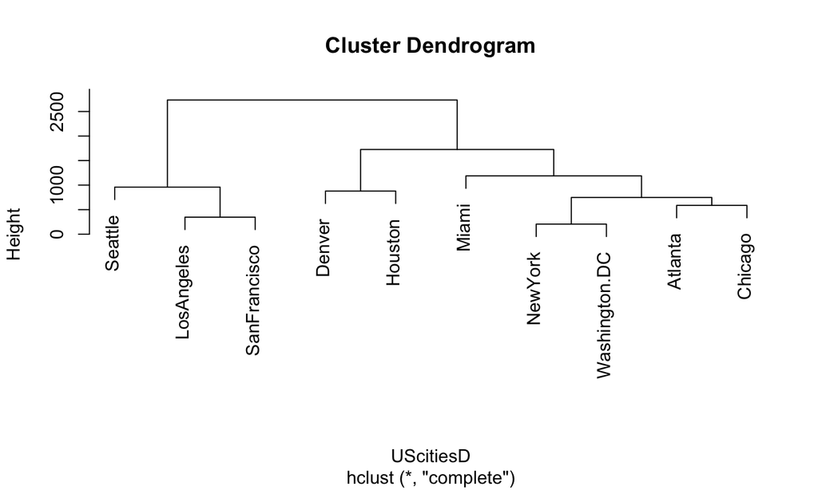

```r
uscities.complete.link <- hclust(UScitiesD, method = "complete")
plot(uscities.complete.link)
```

## Clustering: `hclust`

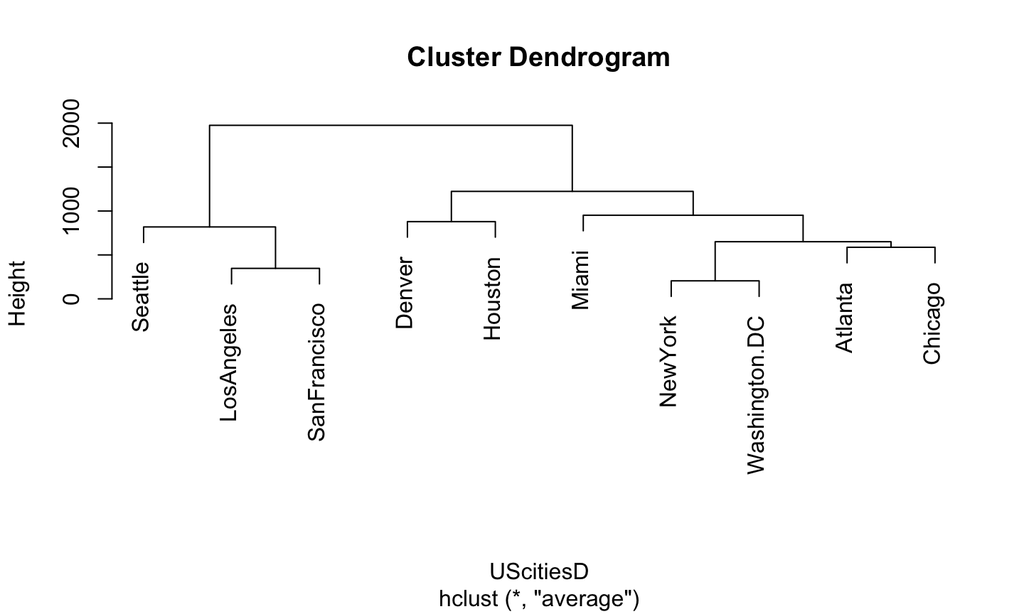

```r
uscities.average.link <- hclust(UScitiesD, method = "average")
plot(uscities.average.link)
```

## Clustering: Ejercicios

- Calcula los clusters en los datos de `faithful` usando `kmeans` y `pam`.
- Calcula y grafica los clusters en `eurodist` con `hclust`.

## Clustering: Ejercicios

- Solución (1era parte)
  - Disponible después de la fecha de entrega.

## Clustering: Ejercicios

- Solución (2nda parte)
  - Disponible después de la fecha de entrega.

## Clustering: Ejercicios

- Solución (3era parte)
  - Disponible después de la fecha de entrega.

## Licencia CC BY

Estadística y Manejo de Datos con R (EMDR) por Marcos F. Rosetti S. y Luis Pacheco-Cobos se distribuye bajo una [Licencia Creative Commons Atribución 4.0 Internacional](http://creativecommons.org/licenses/by/4.0/).